# lunchtime8 slides

# Lunch Time Python #8: ipywidgets

*Jupyter Notebooks* are a perfect fit for scientific work with Python. They combine the following elements:

- Code
- Documentation
- Visualization
- **UI Controls**

This allows us to write scientifically meaningful, executable documents that contain results, their interpretation and their provenance. They are a key element for reproducible research.

## What are widgets?

Jupyter has a so-called *rich display system*. If Python code returns an object, Jupyter accesses special methods on the object to decide how to display it. This can involve pretty printing, HTML, images, video, sounds etc:

```python
from PIL import Image
from io import BytesIO
import requests
```

```python
response = requests.get(
    "https://ssciwr.github.io/lunch-time-python/lunchtime5/thingstaette.png"
)
img = Image.open(BytesIO(response.content))
```

```python
?img._repr_png_
```

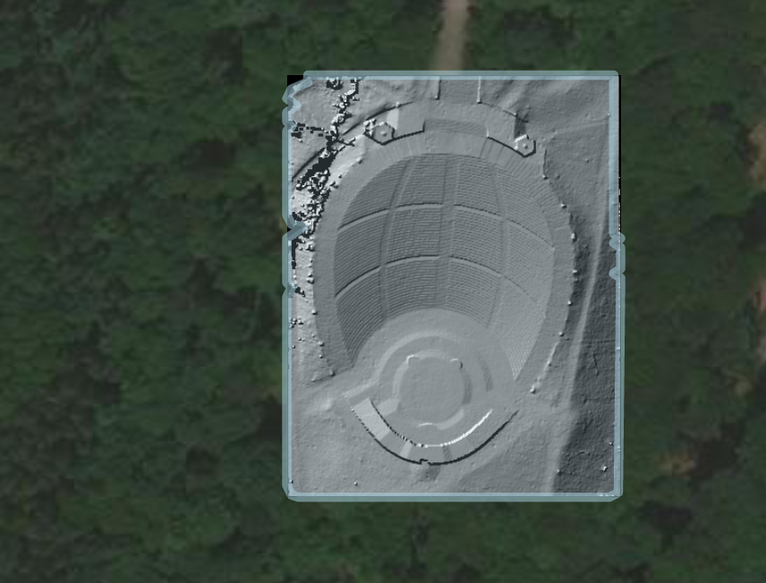

```python
img
```

`ipywidgets` provides a number of widgets that are Python objects that display as HTML. The interactive behaviour of this HTML snippet is implemented in JavaScript and uses callback functions in Python. This way, you write interactive notebooks with pure Python.

```python
import ipywidgets
```

```python
button = ipywidgets.Button(description="Click Me!")
```

```python
button
```

```python
def handler(change):
    button.description = "Thanks!"
```

```python
button.on_click(handler)
```

## Input widgets (I)

We can create simple input fields that allow users to put in data. We can then access that data from Python reading and writing:

```python
widget = ipywidgets.Text()
```

```python
widget
```

```python
widget.value
```

```
''
```

```python
widget.value = "Test"
```

## Input widgets (II)

Many similar working subflavors exist (for a full list see [the docs](https://ipywidgets.readthedocs.io/en/latest/examples/Widget%20List.html)):

```python
ipywidgets.FloatText(value=42.0, step=0.01)
```

```python
ipywidgets.IntSlider(min=-10, max=10)
```

```python
ipywidgets.Checkbox(value=True, description="Some Option")
```

## Selection widgets

```python
widget = ipywidgets.Dropdown(options=["Model A", "Model B", "Model C"])
```

```python
widget
```

```python
widget.value
```

```
'Model A'
```

```python
ipywidgets.RadioButtons(options=["Model A", "Model B", "Model C"])
```

```python
ipywidgets.Select(options=["Linux", "Windows", "macOS"], description="OS:")
```

## Container widgets

If multiple widgets should be placed together, possibly applying some styling, they can be grouped into container widgets. In contrast to other widgets, these do not have an accessible `value`, but some have `selected_index`:

```python
widgets = [ipywidgets.Text(value=f"#{i}") for i in range(4)]
```

```python
ipywidgets.HBox(children=widgets)
```

```python
ipywidgets.VBox(children=widgets)
```

```python
ipywidgets.Accordion(children=widgets, titles=tuple(f"Tab #{i}" for i in range(4)))
```

```python
tab = ipywidgets.Tab(children=widgets, titles=tuple(f"Tab #{i}" for i in range(4)))
```

```python
tab
```

```python
tab.selected_index
```

```
0
```

## Putting things together

```python
import io


def img_to_widget(i):
    membuf = io.BytesIO()
    i.save(membuf, format="png")
    return ipywidgets.Image(value=membuf.getvalue(), format="png")
```

```python
img_widget = img_to_widget(img)
cropped_widget = img_to_widget(img)
```

```python
x0 = ipywidgets.IntText(value=0, layout=ipywidgets.Layout(width="100px"))
y0 = ipywidgets.IntText(value=0, layout=ipywidgets.Layout(width="100px"))
x1 = ipywidgets.IntText(value=img.size[0], layout=ipywidgets.Layout(width="100px"))
y1 = ipywidgets.IntText(value=img.size[1], layout=ipywidgets.Layout(width="100px"))
```

```python
controls = ipywidgets.VBox(
    children=[
        ipywidgets.VBox(children=[ipywidgets.Label("Upper left:"), x0, y0]),
        ipywidgets.VBox(children=[ipywidgets.Label("Lower right:"), x1, y1]),
    ]
)
```

```python
def crop_handler(_):
    cropped_widget.value = img_to_widget(
        img.crop([x0.value, y0.value, x1.value, y1.value])
    ).value


x0.observe(crop_handler, names="value")
y0.observe(crop_handler, names="value")
x1.observe(crop_handler, names="value")
y1.observe(crop_handler, names="value")
```

```python
app = ipywidgets.AppLayout(
    left_sidebar=controls,
    center=img_widget,
    right_sidebar=cropped_widget,
    pane_widths=(1, 2, 2),
)
```

```python
app
```

## A simple alternative - interact

`ipywidgets` contains a much simpler interface that automatically creates widgets for you. You simply need to annotate ("decorate") a function that does something and you will get a continuously updated interactive version:

```python
@ipywidgets.interact(x=(0, 100), y=(0, 100))
def add(x, y):
    return x + y
```

Notably, this does not change the function nature of `add`. It is merely displaying a UI as a side effect of the function definition:

```python
?add
```

`ipywidgets.interact` has many more options and flavors. Here are some:

```python
@ipywidgets.interact(
    operation=[("add", 1.0), ("subtract", -1.0)],
    rounding=False,
    x=(0, 100, 0.1),
    y=(0, 100, 0.1),
)
def op(operation, rounding, x, y):
    val = x * operation + y
    if rounding:
        return round(val)
    else:
        return val
```

```python
import time
```

```python
@ipywidgets.interact_manual(x=(0, 100), y=(0, 100))
def slow_add(x, y):
    time.sleep(1)
    return x + y
```

## More information

For more information, see the `ipywidgets` documentation:

https://ipywidgets.readthedocs.io